# DSBD-Project_2

## Team 12 - Medical Appointment No-Show

### Manali Killedar and Karan Shah

```python
import warnings
warnings.filterwarnings('ignore')
```

```python
import pandas as pd
import numpy as np
import datetime
import matplotlib.pyplot as plt
import seaborn as sbs
#import pandas_profiling

import numpy as np
import pandas as pd
from sklearn.utils import shuffle
from sklearn.linear_model import LogisticRegression
from sklearn.model_selection import train_test_split
import pandas_profiling

from sklearn.naive_bayes import BernoulliNB
from sklearn.ensemble import RandomForestClassifier
from sklearn.cluster import KMeans
from sklearn.metrics import accuracy_score, roc_curve, roc_auc_score, f1_score
from sklearn.model_selection import KFold, GridSearchCV
from sklearn.utils import resample

#for images
from IPython.display import Image
```

## I. Introduction and Motivation

The medical/healthcare industry is moving rapidly towards analytics. People make appointments with doctors, follow all the instructions, receive messages reminding them of their appointments, and yet they still end up missing their appointments. According to sources, it costs US health care system $150 billion a year when patients miss the appointments. What if it was possible to predict no-shows? If we are able to predict the show ups, we can optimize the usage of the resources and schedule maximum appointments in a day.

The domain of the problem is a pure binary classification task (supervised learning). To make it a little more interesting, we want to see how unsupervised learning can be implemented within a supervised learning task.

We took data from Kaggle : https://www.kaggle.com/joniarroba/noshowappointments/home. This data is from hospitals in a region from Brazil for three months in 2016.

## II. Read in Data

```python
parse_dates = ['AppointmentDay', 'ScheduledDay']
data_raw = pd.read_csv('KaggleV2-May-2016.csv', parse_dates=parse_dates)
```

```python
data_raw.head(5)
```

|  | PatientId | AppointmentID | Gender | ScheduledDay | AppointmentDay | Age | Neighbourhood | Scholarship | Hipertension | Diabetes | Alcoholism | Handcap | SMS_received | No-show |
| --- | --- | --- | --- | --- | --- | --- | --- | --- | --- | --- | --- | --- | --- | --- |
| 0 | 2.987250e+13 | 5642903 | F | 2016-04-29 18:38:08 | 2016-04-29 | 62 | JARDIM DA PENHA | 0 | 1 | 0 | 0 | 0 | 0 | No |
| 1 | 5.589980e+14 | 5642503 | M | 2016-04-29 16:08:27 | 2016-04-29 | 56 | JARDIM DA PENHA | 0 | 0 | 0 | 0 | 0 | 0 | No |
| 2 | 4.262960e+12 | 5642549 | F | 2016-04-29 16:19:04 | 2016-04-29 | 62 | MATA DA PRAIA | 0 | 0 | 0 | 0 | 0 | 0 | No |
| 3 | 8.679510e+11 | 5642828 | F | 2016-04-29 17:29:31 | 2016-04-29 | 8 | PONTAL DE CAMBURI | 0 | 0 | 0 | 0 | 0 | 0 | No |
| 4 | 8.841190e+12 | 5642494 | F | 2016-04-29 16:07:23 | 2016-04-29 | 56 | JARDIM DA PENHA | 0 | 1 | 1 | 0 | 0 | 0 | No |

We have 14 variables in our dat, with 110527 observations. The split of our different variables is shown below using Pandas Profiling.

Overview

Dataset info

| Number of variables | 14 |
| --- | --- |
| Number of observations | 110527 |
| Total Missing (%) | 0.0% |
| Total size in memory | 11.8 MiB |
| Average record size in memory | 112.0 B |

Variables types

| Numeric | 4 |
| --- | --- |
| Categorical | 3 |
| Boolean | 5 |
| Date | 2 |
| Text (Unique) | 0 |
| Rejected | 0 |
| Unsupported | 0 |

Warnings

- `Age` has 3539 / 3.2% zeros Zeros

- `Handcap` has 108286 / 98.0% zeros Zeros

- `Neighbourhood` has a high cardinality: 81 distinct values Warning

Variables

Age  
Numeric

| Distinct count | 104 |
| --- | --- |
| Unique (%) | 0.1% |
| Missing (%) | 0.0% |
| Missing (n) | 0 |
| Infinite (%) | 0.0% |
| Infinite (n) | 0 |

| Mean | 37.089 |
| --- | --- |
| Minimum | -1 |
| Maximum | 115 |
| Zeros (%) | 3.2% |

Toggle details

**Statistics**

Quantile statistics

| Minimum | -1 |
| --- | --- |
| 5-th percentile | 1 |
| Q1 | 18 |
| Median | 37 |
| Q3 | 55 |
| 95-th percentile | 75 |
| Maximum | 115 |
| Range | 116 |
| Interquartile range | 37 |

Descriptive statistics

| Standard deviation | 23.11 |
| --- | --- |
| Coef of variation | 0.6231 |
| Kurtosis | -0.95227 |
| Mean | 37.089 |
| MAD | 19.662 |
| Skewness | 0.12166 |
| Sum | 4099322 |
| Variance | 534.08 |
| Memory size | 863.6 KiB |

**Histogram**

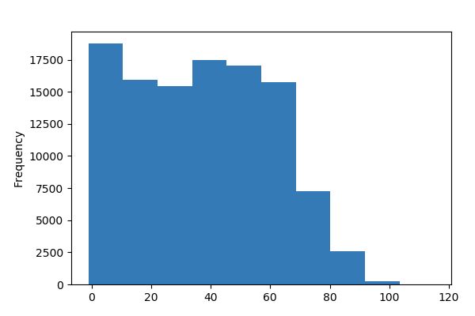

**Common Values**

| Value | Count | Frequency (%) |  |
| --- | --- | --- | --- |
| 0 | 3539 | 3.2% |  |
| 1 | 2273 | 2.1% |  |
| 52 | 1746 | 1.6% |  |
| 49 | 1652 | 1.5% |  |
| 53 | 1651 | 1.5% |  |
| 56 | 1635 | 1.5% |  |
| 38 | 1629 | 1.5% |  |
| 59 | 1624 | 1.5% |  |
| 2 | 1618 | 1.5% |  |
| 50 | 1613 | 1.5% |  |
| Other values (94) | 91547 | 82.8% |  |

**Extreme Values**

Minimum 5 values

| Value | Count | Frequency (%) |  |
| --- | --- | --- | --- |
| -1 | 1 | 0.0% |  |
| 0 | 3539 | 3.2% |  |
| 1 | 2273 | 2.1% |  |
| 2 | 1618 | 1.5% |  |
| 3 | 1513 | 1.4% |  |

Maximum 5 values

| Value | Count | Frequency (%) |  |
| --- | --- | --- | --- |
| 98 | 6 | 0.0% |  |
| 99 | 1 | 0.0% |  |
| 100 | 4 | 0.0% |  |
| 102 | 2 | 0.0% |  |
| 115 | 5 | 0.0% |  |

Alcoholism  
Boolean

| Distinct count | 2 |
| --- | --- |
| Unique (%) | 0.0% |
| Missing (%) | 0.0% |
| Missing (n) | 0 |

| Mean | 0.0304 |
| --- | --- |

| 0 | 107167 |
| --- | --- |
| 1 | 3360 |

Toggle details

| Value | Count | Frequency (%) |  |
| --- | --- | --- | --- |
| 0 | 107167 | 97.0% |  |
| 1 | 3360 | 3.0% |  |

AppointmentDay  
Date

| Distinct count | 27 |
| --- | --- |
| Unique (%) | 0.0% |
| Missing (%) | 0.0% |
| Missing (n) | 0 |
| Infinite (%) | 0.0% |
| Infinite (n) | 0 |

| Minimum | 2016-04-29 00:00:00 |
| --- | --- |
| Maximum | 2016-06-08 00:00:00 |

Toggle details

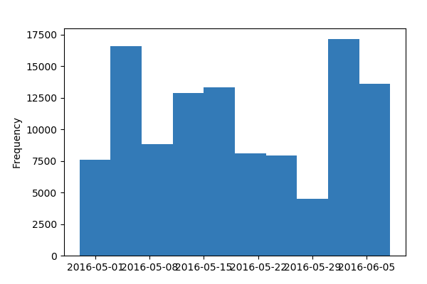

AppointmentID  
Numeric

| Distinct count | 110527 |
| --- | --- |
| Unique (%) | 100.0% |
| Missing (%) | 0.0% |
| Missing (n) | 0 |
| Infinite (%) | 0.0% |
| Infinite (n) | 0 |

| Mean | 5675300 |
| --- | --- |
| Minimum | 5030230 |
| Maximum | 5790484 |
| Zeros (%) | 0.0% |

Toggle details

**Statistics**

Quantile statistics

| Minimum | 5030230 |
| --- | --- |
| 5-th percentile | 5548200 |
| Q1 | 5640300 |
| Median | 5680600 |
| Q3 | 5725500 |
| 95-th percentile | 5773500 |
| Maximum | 5790484 |
| Range | 760254 |
| Interquartile range | 85238 |

Descriptive statistics

| Standard deviation | 71296 |
| --- | --- |
| Coef of variation | 0.012562 |
| Kurtosis | 3.7438 |
| Mean | 5675300 |
| MAD | 53569 |
| Skewness | -1.2356 |
| Sum | 627274449377 |
| Variance | 5083100000 |
| Memory size | 863.6 KiB |

**Histogram**

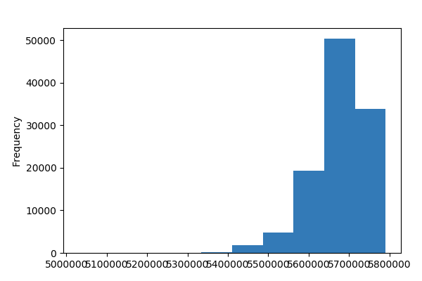

**Common Values**

| Value | Count | Frequency (%) |  |
| --- | --- | --- | --- |
| 5769215 | 1 | 0.0% |  |
| 5731652 | 1 | 0.0% |  |
| 5707080 | 1 | 0.0% |  |
| 5702986 | 1 | 0.0% |  |
| 5715276 | 1 | 0.0% |  |
| 5717325 | 1 | 0.0% |  |
| 5711182 | 1 | 0.0% |  |
| 5758289 | 1 | 0.0% |  |
| 5762391 | 1 | 0.0% |  |
| 5741913 | 1 | 0.0% |  |
| Other values (110517) | 110517 | 100.0% |  |

**Extreme Values**

Minimum 5 values

| Value | Count | Frequency (%) |  |
| --- | --- | --- | --- |
| 5030230 | 1 | 0.0% |  |
| 5122866 | 1 | 0.0% |  |
| 5134197 | 1 | 0.0% |  |
| 5134220 | 1 | 0.0% |  |
| 5134223 | 1 | 0.0% |  |

Maximum 5 values

| Value | Count | Frequency (%) |  |
| --- | --- | --- | --- |
| 5790461 | 1 | 0.0% |  |
| 5790464 | 1 | 0.0% |  |
| 5790466 | 1 | 0.0% |  |
| 5790481 | 1 | 0.0% |  |
| 5790484 | 1 | 0.0% |  |

Diabetes  
Boolean

| Distinct count | 2 |
| --- | --- |
| Unique (%) | 0.0% |
| Missing (%) | 0.0% |
| Missing (n) | 0 |

| Mean | 0.071865 |
| --- | --- |

| 0 | 102584 |
| --- | --- |
| 1 | 7943 |

Toggle details

| Value | Count | Frequency (%) |  |
| --- | --- | --- | --- |
| 0 | 102584 | 92.8% |  |
| 1 | 7943 | 7.2% |  |

Gender  
Categorical

| Distinct count | 2 |
| --- | --- |
| Unique (%) | 0.0% |
| Missing (%) | 0.0% |
| Missing (n) | 0 |

| F | 71840 |
| --- | --- |
| M | 38687 |

Toggle details

| Value | Count | Frequency (%) |  |
| --- | --- | --- | --- |
| F | 71840 | 65.0% |  |
| M | 38687 | 35.0% |  |

Handcap  
Numeric

| Distinct count | 5 |
| --- | --- |
| Unique (%) | 0.0% |
| Missing (%) | 0.0% |
| Missing (n) | 0 |
| Infinite (%) | 0.0% |
| Infinite (n) | 0 |

| Mean | 0.022248 |
| --- | --- |
| Minimum | 0 |
| Maximum | 4 |
| Zeros (%) | 98.0% |

Toggle details

**Statistics**

Quantile statistics

| Minimum | 0 |
| --- | --- |
| 5-th percentile | 0 |
| Q1 | 0 |
| Median | 0 |
| Q3 | 0 |
| 95-th percentile | 0 |
| Maximum | 4 |
| Range | 4 |
| Interquartile range | 0 |

Descriptive statistics

| Standard deviation | 0.16154 |
| --- | --- |
| Coef of variation | 7.261 |
| Kurtosis | 82.556 |
| Mean | 0.022248 |
| MAD | 0.043594 |
| Skewness | 8.2744 |
| Sum | 2459 |
| Variance | 0.026096 |
| Memory size | 863.6 KiB |

**Histogram**

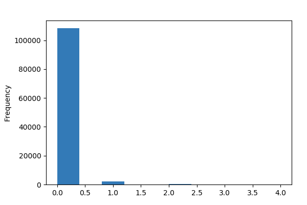

**Common Values**

| Value | Count | Frequency (%) |  |
| --- | --- | --- | --- |
| 0 | 108286 | 98.0% |  |
| 1 | 2042 | 1.8% |  |
| 2 | 183 | 0.2% |  |
| 3 | 13 | 0.0% |  |
| 4 | 3 | 0.0% |  |

**Extreme Values**

Minimum 5 values

| Value | Count | Frequency (%) |  |
| --- | --- | --- | --- |
| 0 | 108286 | 98.0% |  |
| 1 | 2042 | 1.8% |  |
| 2 | 183 | 0.2% |  |
| 3 | 13 | 0.0% |  |
| 4 | 3 | 0.0% |  |

Maximum 5 values

| Value | Count | Frequency (%) |  |
| --- | --- | --- | --- |
| 0 | 108286 | 98.0% |  |
| 1 | 2042 | 1.8% |  |
| 2 | 183 | 0.2% |  |
| 3 | 13 | 0.0% |  |
| 4 | 3 | 0.0% |  |

Hipertension  
Boolean

| Distinct count | 2 |
| --- | --- |
| Unique (%) | 0.0% |
| Missing (%) | 0.0% |
| Missing (n) | 0 |

| Mean | 0.19725 |
| --- | --- |

| 0 | 88726 |
| --- | --- |
| 1 | 21801 |

Toggle details

| Value | Count | Frequency (%) |  |
| --- | --- | --- | --- |
| 0 | 88726 | 80.3% |  |
| 1 | 21801 | 19.7% |  |

Neighbourhood  
Categorical

| Distinct count | 81 |
| --- | --- |
| Unique (%) | 0.1% |
| Missing (%) | 0.0% |
| Missing (n) | 0 |

| JARDIM CAMBURI | 7717 |
| --- | --- |
| MARIA ORTIZ | 5805 |
| RESISTÊNCIA | 4431 |
| Other values (78) | 92574 |

Toggle details

| Value | Count | Frequency (%) |  |
| --- | --- | --- | --- |
| JARDIM CAMBURI | 7717 | 7.0% |  |
| MARIA ORTIZ | 5805 | 5.3% |  |
| RESISTÊNCIA | 4431 | 4.0% |  |
| JARDIM DA PENHA | 3877 | 3.5% |  |
| ITARARÉ | 3514 | 3.2% |  |
| CENTRO | 3334 | 3.0% |  |
| TABUAZEIRO | 3132 | 2.8% |  |
| SANTA MARTHA | 3131 | 2.8% |  |
| JESUS DE NAZARETH | 2853 | 2.6% |  |
| BONFIM | 2773 | 2.5% |  |
| Other values (71) | 69960 | 63.3% |  |

No-show  
Categorical

| Distinct count | 2 |
| --- | --- |
| Unique (%) | 0.0% |
| Missing (%) | 0.0% |
| Missing (n) | 0 |

| No | 88208 |
| --- | --- |
| Yes | 22319 |

Toggle details

| Value | Count | Frequency (%) |  |
| --- | --- | --- | --- |
| No | 88208 | 79.8% |  |
| Yes | 22319 | 20.2% |  |

PatientId  
Numeric

| Distinct count | 62299 |
| --- | --- |
| Unique (%) | 56.4% |
| Missing (%) | 0.0% |
| Missing (n) | 0 |
| Infinite (%) | 0.0% |
| Infinite (n) | 0 |

| Mean | 147500000000000 |
| --- | --- |
| Minimum | 39218 |
| Maximum | 999980000000000 |
| Zeros (%) | 0.0% |

Toggle details

**Statistics**

Quantile statistics

| Minimum | 39218 |
| --- | --- |
| 5-th percentile | 137030000000 |
| Q1 | 4172600000000 |
| Median | 31732000000000 |
| Q3 | 94392000000000 |
| 95-th percentile | 818550000000000 |
| Maximum | 999980000000000 |
| Range | 999980000000000 |
| Interquartile range | 90219000000000 |

Descriptive statistics

| Standard deviation | 256090000000000 |
| --- | --- |
| Coef of variation | 1.7363 |
| Kurtosis | 2.5829 |
| Mean | 147500000000000 |
| MAD | 186340000000000 |
| Skewness | 1.9677 |
| Sum | 1.6302e+19 |
| Variance | 6.5585e+28 |
| Memory size | 863.6 KiB |

**Histogram**

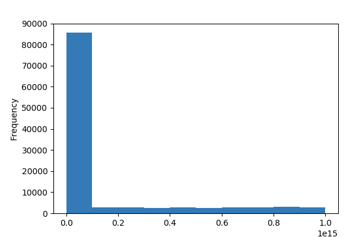

**Common Values**

| Value | Count | Frequency (%) |  |
| --- | --- | --- | --- |
| 822145925426128.0 | 88 | 0.1% |  |
| 99637671331.0 | 84 | 0.1% |  |
| 26886125921145.0 | 70 | 0.1% |  |
| 33534783483176.0 | 65 | 0.1% |  |
| 258424392677.0 | 62 | 0.1% |  |
| 75797461494159.0 | 62 | 0.1% |  |
| 871374938638855.0 | 62 | 0.1% |  |
| 6264198675331.0 | 62 | 0.1% |  |
| 66844879846766.0 | 57 | 0.1% |  |
| 872278549442.0 | 55 | 0.0% |  |
| Other values (62289) | 109860 | 99.4% |  |

**Extreme Values**

Minimum 5 values

| Value | Count | Frequency (%) |  |
| --- | --- | --- | --- |
| 39217.84439 | 1 | 0.0% |  |
| 43741.756519999995 | 1 | 0.0% |  |
| 93779.52927 | 1 | 0.0% |  |
| 141724.16655 | 1 | 0.0% |  |
| 537615.2847600001 | 1 | 0.0% |  |

Maximum 5 values

| Value | Count | Frequency (%) |  |
| --- | --- | --- | --- |
| 999931985292928.0 | 5 | 0.0% |  |
| 999934989273974.0 | 1 | 0.0% |  |
| 999946536742891.0 | 1 | 0.0% |  |
| 999968578354866.0 | 1 | 0.0% |  |
| 999981631772427.0 | 1 | 0.0% |  |

SMS_received  
Boolean

| Distinct count | 2 |
| --- | --- |
| Unique (%) | 0.0% |
| Missing (%) | 0.0% |
| Missing (n) | 0 |

| Mean | 0.32103 |
| --- | --- |

| 0 | 75045 |
| --- | --- |
| 1 | 35482 |

Toggle details

| Value | Count | Frequency (%) |  |
| --- | --- | --- | --- |
| 0 | 75045 | 67.9% |  |
| 1 | 35482 | 32.1% |  |

ScheduledDay  
Date

| Distinct count | 103549 |
| --- | --- |
| Unique (%) | 93.7% |
| Missing (%) | 0.0% |
| Missing (n) | 0 |
| Infinite (%) | 0.0% |
| Infinite (n) | 0 |

| Minimum | 2015-11-10 07:13:56 |
| --- | --- |
| Maximum | 2016-06-08 20:07:23 |

Toggle details

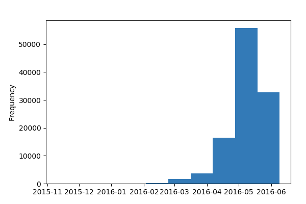

Scholarship  
Boolean

| Distinct count | 2 |
| --- | --- |
| Unique (%) | 0.0% |
| Missing (%) | 0.0% |
| Missing (n) | 0 |

| Mean | 0.098266 |
| --- | --- |

| 0 | 99666 |
| --- | --- |
| 1 | 10861 |

Toggle details

| Value | Count | Frequency (%) |  |
| --- | --- | --- | --- |
| 0 | 99666 | 90.2% |  |
| 1 | 10861 | 9.8% |  |

Correlations

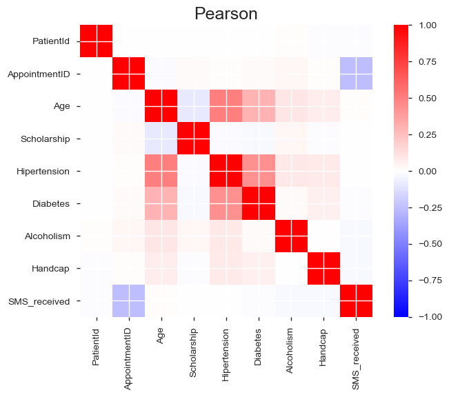

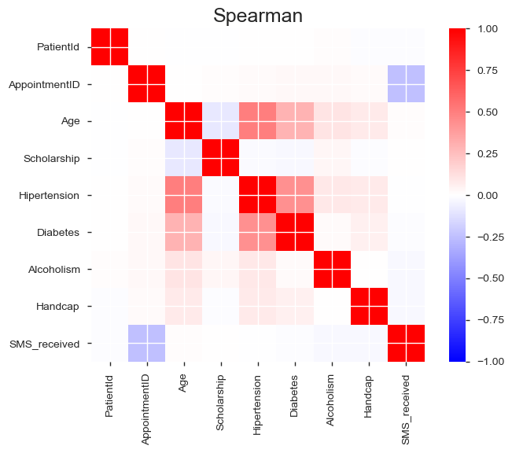

Sample

|  | PatientId | AppointmentID | Gender | ScheduledDay | AppointmentDay | Age | Neighbourhood | Scholarship | Hipertension | Diabetes | Alcoholism | Handcap | SMS_received | No-show |
| --- | --- | --- | --- | --- | --- | --- | --- | --- | --- | --- | --- | --- | --- | --- |
| 0 | 2.987250e+13 | 5642903 | F | 2016-04-29 18:38:08 | 2016-04-29 | 62 | JARDIM DA PENHA | 0 | 1 | 0 | 0 | 0 | 0 | No |
| 1 | 5.589978e+14 | 5642503 | M | 2016-04-29 16:08:27 | 2016-04-29 | 56 | JARDIM DA PENHA | 0 | 0 | 0 | 0 | 0 | 0 | No |
| 2 | 4.262962e+12 | 5642549 | F | 2016-04-29 16:19:04 | 2016-04-29 | 62 | MATA DA PRAIA | 0 | 0 | 0 | 0 | 0 | 0 | No |
| 3 | 8.679512e+11 | 5642828 | F | 2016-04-29 17:29:31 | 2016-04-29 | 8 | PONTAL DE CAMBURI | 0 | 0 | 0 | 0 | 0 | 0 | No |
| 4 | 8.841186e+12 | 5642494 | F | 2016-04-29 16:07:23 | 2016-04-29 | 56 | JARDIM DA PENHA | 0 | 1 | 1 | 0 | 0 | 0 | No |

```python
pandas_profiling.ProfileReport(data_raw)
```

### Correlation

Pandas Profiling gave a very detailed overview of how different features look. In the Pearson correlation graph we can see that none of the features are very highly correlated. It is seen that Hyper-tension and diabetes are relatively correlated but not high enough to be dropped.

## III. Data Cleaning

```python
#Check if any of the rows has any nan values
print('Are there any missing values? {}.'.format(data_raw.isnull().values.any()))
```

```
Are there any missing values? False.
```

```python
#Check the minimum age
print('The minimum age is: ', min(data_raw['Age']))
#Check the maximum age
print('The maximum age is: ', max(data_raw['Age']))
#age of -1 as minimum doesnt make sense, so remove the rows with -1
patient_id = list(data_raw[data_raw['Age'] == min(data_raw['Age'])]['PatientId'])
data_raw = data_raw[~data_raw['PatientId'].isin(patient_id)]
#remove time component from scheduled day because it interferes with features
data_raw['ScheduledDay'] = data_raw['ScheduledDay'].map(lambda val: datetime.datetime.strptime(str(val).strip().split()[0],'%Y-%m-%d'))
#remove rows where appointment is less than scheduled day
data_raw = data_raw.loc[data_raw['AppointmentDay'] >= data_raw['ScheduledDay'], :]
```

```
The minimum age is:  -1
The maximum age is:  115
```

The data included patients with negative age, so we removed such rows. In addition, we removed the time component from scheduled day because it interfered with our calculations for some of the features we extracted. Last, we removed rows where the appointment is less than the scheduled day as you can't schedule an appointment for a prior day.

```python
print('After cleaning, the final dataset incldues {} rows and {} columns.'.format(data_raw.shape[0],data_raw.shape[1]))
```

```
After cleaning, the final dataset incldues 110521 rows and 14 columns.
```

## IV. EDA

```python
data_raw_encode_eda = data_raw.copy()
```

```python
#Split the age in different categories. We take -1 so that zero is inclusive
bins = [-1,2,12,18,35,60,np.inf]
age_labels=["Baby","Child","Teenager","Young adults", "Adult","Elder"]
age_cat = pd.cut(data_raw_encode_eda.Age,bins,labels=age_labels)
#making age category as object type so that encoding works
data_raw_encode_eda['Age_category'] = age_cat
```

```python
data_raw_encode_eda.to_csv('noshowappointments_eda.csv')
```

### Below are few EDAs done using Tableau.

1. The first one shows Show-No Show pattern in different age groups and across different gender. As we can see, for kids there is no gender gap, but as people grow old, it was seen that females tend to miss appointments more than males do.

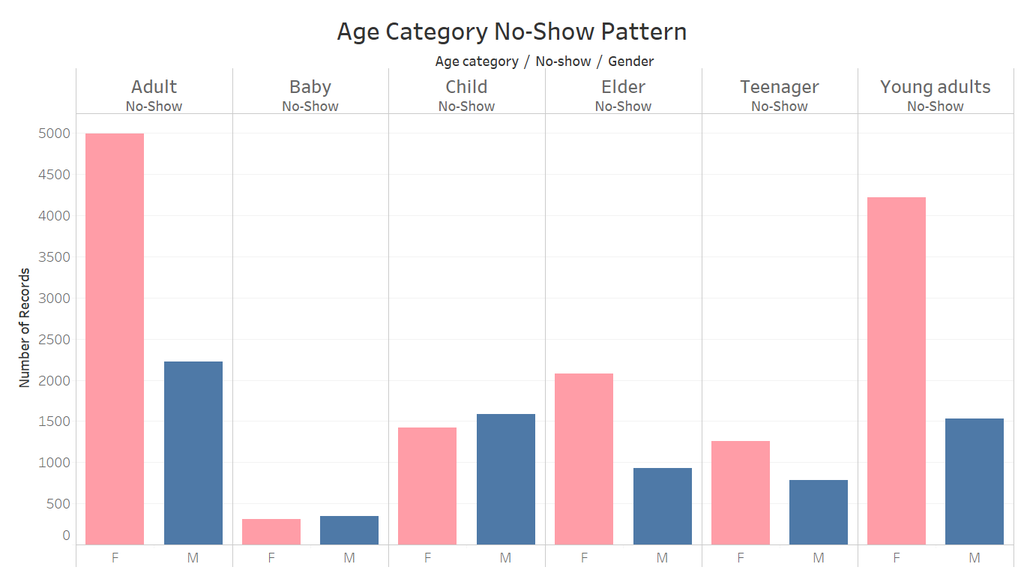

```python
Image(filename='age_gender.png')
```

1. The second EDA is about show- no show across both the genders. It was seen that females book more appointments in general but they also tend to miss appointments more than men, which could be because they are in higher proportion in the data

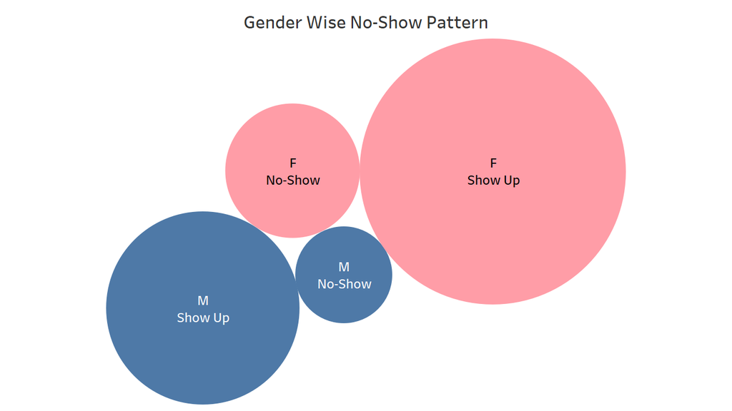

```python
Image(filename='gender.png')
```

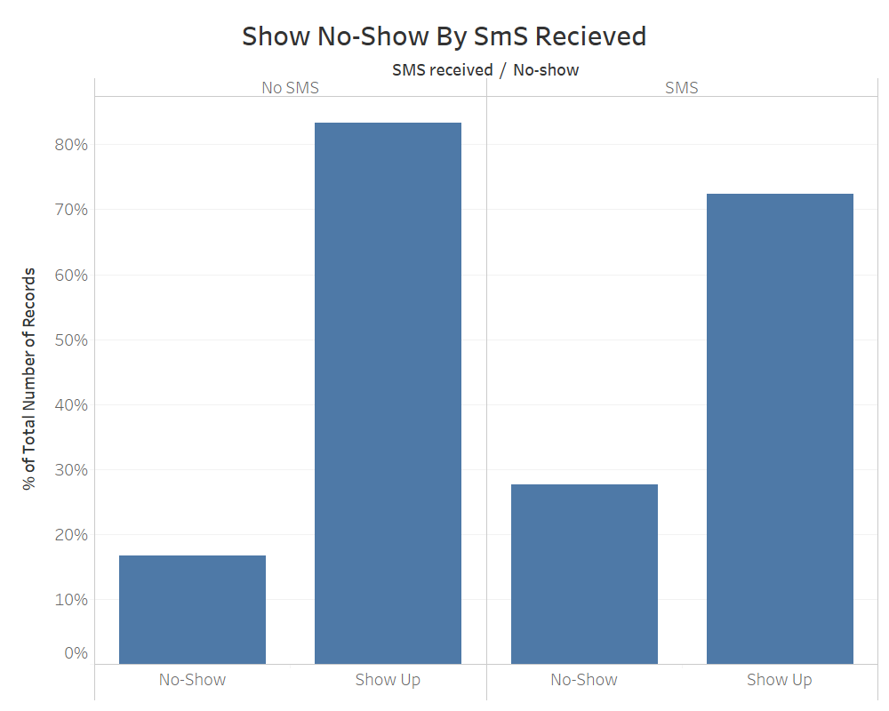

```python
Image(filename='sms_noShow.png')
```

## V. Functions

Below are some functions that we have reused throughout the project.

The encoding method takes a dataframe and does label encoding or one-hot encoding depending upon the number of unique columns in the column in the data frame and returns the new data frame.

The train class has two method of cluster and classify. We use to either do clustering on the data set that is passed or do classification depending on which function is called. We can pass different models to these functions and the function will take of it accordingly. The result of the clustering technique will be used as a feature.

```python
def encoding(df):
    column_types = df.dtypes
    objectType_cols = list(column_types[column_types=='object'].index)
    for cols in objectType_cols:
        if(len(df[cols].unique())>2):
            label_encode = pd.get_dummies(df[cols])
            df.drop(cols,axis=1, inplace=True)
            df = pd.merge(df,label_encode,left_index=True, right_index=True)
        elif(len(df[cols].unique())==2):
            df[cols].replace(df[cols].unique(),[0,1],inplace=True)
    return df
```

```python
class train(object):
    def __init__(self, train, test):
        train_data = train.copy()
        test_data = test.copy()

        n,m = train.shape

        self.X_train, self.y_train = train_data.iloc[:,:m-1], train_data.iloc[:,m-1]
        self.X_test, self.y_test = test_data.iloc[:, :m-1], test_data.iloc[:, m-1]

    def classify(self, model=LogisticRegression(random_state=42)): #default classification model is Logistic Regression
        model.fit(self.X_train, self.y_train)
        if(isinstance(model,RandomForestClassifier)):
            feature_importances = pd.DataFrame(model.feature_importances_,index = self.X_train.columns,columns=['importance']).sort_values('importance',ascending=False)
            print(feature_importances.head(5))

        y_pred = model.predict_proba(self.X_test)[:,1]
        return(self.y_test, y_pred)

    def cluster(self, model=KMeans(n_clusters=2, random_state=42), output='add'): #default clustering model is Kmeans
        model.fit(self.X_train)
        y_labels_train = model.labels_
        y_labels_test = model.predict(self.X_test)
        if output == 'add':
            self.X_train['km_clust'] = y_labels_train
            self.X_test['km_clust'] = y_labels_test
        else:
            raise ValueError('output should be add')

        return self
```

## Methodology of our analysis

Step 1: One Hot Encoding Step 2: Train/Test Split Step 3: Hyper Parameter Tuning Step 4: Pass Models (Logistic Regression, Naive Bayes, and Random Forest) with the optimal parameters from Step 3 to a Cross Validation Class to perform model fitting and prediction Step 5: Repeat Process: a. After fixing class imbalance b. After fixing class imbalance and performing feature engineering and re-tuning the models

## VI. Analysis

### 1. Split Data into Train-Test

```python
X_train,X_test = train_test_split(encoding(data_raw), test_size=0.20, random_state=42)
```

We split our encoded data into X_train and X_test using a 80/20 split. The X_test will be used to evaluate our final model at the end.

```python
#Preparing the data
kaggle = X_train.copy()
#Dropped appointmentday and scheduleday
kaggle.drop(['AppointmentDay','ScheduledDay'], axis=1,inplace=True)
#getting the output column at the end
kaggle['NoShow'] = kaggle['No-show']
kaggle.drop(['No-show'], axis=1,inplace=True)
```

In the cell above, we create a copy of X_train, and we call it kaggle. We move the output column No-show as the last column of kaggle. We need to do this in order for our previous train class object to work. At this stage, we want to our tune our classifiers and test them on the data without any modifications.

### 2. Hyperparameter Tuning

#### a. Hyperparameter Tuning for Logistic Regression

```python
logistic = LogisticRegression()
C = [1e-2,1e-1,1,10,100]

hyperparameters = dict(C=C)
clf = GridSearchCV(logistic, hyperparameters, cv=5, verbose=0, scoring='roc_auc')

n,m = kaggle.shape
X, Y = kaggle.iloc[:,:m-1], kaggle.iloc[:,m-1]
best_model = clf.fit(X, Y)

print('Best Parameters',clf.best_params_)
print('Best C:', best_model.best_estimator_.get_params()['C'])
best_cLR = best_model.best_estimator_.get_params()['C']
```

```
Best Parameters {'C': 0.01}
Best C: 0.01
```

In all of the models, we only tuned one parameter because it would take an unnecessarily long time (approximately 30-40 minutes) to tune many paramaters for each model. For Logistic Regression, we tuned the parameter C. The paramater C is the inverse of regularization strength. Similar to Support Vector Machines, the smaller the value, the stronger the regularization strength. In this case, the best C had a value of 0.01.

We included Logistic Regression because we wanted to test our data using a basic parametric model. However, because logistic regression tends to overfit with more features, we tuned the paramater C in hopes of finding a balance. In our case, the one-hot encoding increased the number of features dramatically.

#### b. Hyperparameter Tuning for Naive Bayes

```python
bNB = BernoulliNB()
alphas = np.array([0.001,0.01,0.1,1,10,100])

hyperparameters = dict(alpha=alphas)
clf = GridSearchCV(bNB, hyperparameters, cv=5, verbose=0, scoring='roc_auc')

n,m = kaggle.shape
X, Y = kaggle.iloc[:,:m-1], kaggle.iloc[:,m-1]
best_model = clf.fit(X, Y)

print('Best Parameters',clf.best_params_)
print('Best Alpha:', best_model.best_estimator_.get_params()['alpha'])
best_alpha = best_model.best_estimator_.get_params()['alpha']
```

```
Best Parameters {'alpha': 1.0}
Best Alpha: 1.0
```

We included Naive Bayes because Naive Bayes does not tend to overfit even if the number of features increases. Again, in our case, the number of features increased because of the one-hot encoding. Therefore, Naive Bayes seemed like a suitable classifier.

We modified the alpha parameter which is an Additive (Laplace/Lidstone) smoothing parameter. In this case, the best alpha was 1 which is the same as the default alpha value.

#### c. Hyperparameter Tuning for Random Forest

```python
rb = RandomForestClassifier()
depths = max_depth = [int(x) for x in np.linspace(2, 50, num = 10)]
print(depths)
hyperparameters = dict(max_depth=depths)
clf = GridSearchCV(rb, hyperparameters, cv=5, verbose=0, scoring='roc_auc')

n,m = kaggle.shape
X, Y = kaggle.iloc[:,:m-1], kaggle.iloc[:,m-1]
best_model = clf.fit(X, Y)

print('Best Parameters',clf.best_params_)
print('Best depth:', best_model.best_estimator_.get_params()['max_depth'])
best_depth = best_model.best_estimator_.get_params()['max_depth']
```

```
[2, 7, 12, 18, 23, 28, 34, 39, 44, 50]
Best Parameters {'max_depth': 18}
Best depth: 18
```

Finally, we included Random Forest because it is a powerful classifier that can allow us to ascertain which features are the most important, and it is also has much less variability that a simple Decision Tree model.

For the Random Forest model, we tuned the depth of the tree, and the best depth was 18.

### 2. Default Modelling

#### a. Logistic Regression Default ROC

```
-----------------------
Accuracy: 0.7986880796199954
F1_sc: 0.0
-----------------------
Accuracy: 0.7957360176440649
F1_sc: 0.0
-----------------------
Accuracy: 0.7985070406605214
F1_sc: 0.0
-----------------------
Accuracy: 0.8026918509302721
F1_sc: 0.0
-----------------------
Accuracy: 0.7960753265848555
F1_sc: 0.0
```

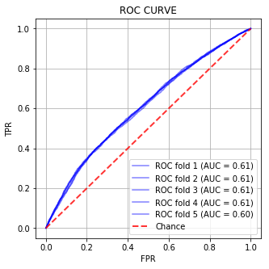

```python
#kfold = Kfold(k=5)
kf = KFold(n_splits=5)
result = pd.DataFrame()
idx = 1
for train_indices, test_indices in kf.split(kaggle):
    train_df = kaggle.iloc[train_indices]
    test_df = kaggle.iloc[test_indices]

    train_patient_label = train_df['PatientId']
    train_appointment_label = train_df['AppointmentID']

    test_patient_label = test_df['PatientId']
    test_appointment_label = test_df['AppointmentID']


    train_df=train_df.drop(columns = ['PatientId','AppointmentID'])
    test_df=test_df.drop(columns = ['PatientId','AppointmentID'])

    y_true, y_pred = train(train_df, test_df).classify(model = LogisticRegression(C=best_cLR,random_state=42))


    temp_df = pd.DataFrame({"PatientId": test_patient_label,"AppointmentId":test_appointment_label, "FOLD": idx, "ACTUAL": y_true, "PREDICTED": y_pred})
    result = result.append(temp_df, ignore_index = True)


    idx += 1


result = result[["PatientId", "AppointmentId", "FOLD", "ACTUAL", "PREDICTED"]]

arity = result['FOLD'].nunique()
pat_id, app_id, fold, actual, pred = result
plt.figure(figsize=(5,5))
for i in range(1, arity+1):
    pred_val, actual_val = result[result[fold] == i][pred].values, result[result[fold] == i][actual].values
    fpr, tpr, thresholds = roc_curve(actual_val, pred_val, pos_label=1)
    auc_roc = np.trapz(tpr, fpr)
    plt.plot(fpr, tpr, linestyle='-', alpha=0.5, color='b', label='ROC fold %d (AUC = %0.2f)' % (i, auc_roc))

    pred_val = list(map(lambda x:1 if x >= 0.5 else 0, pred_val))
    acc = accuracy_score(actual_val, pred_val)
    f1_sc = f1_score(actual_val, pred_val)
    print('-----------------------')
    print('Accuracy: {}'.format(acc))
    print('F1_sc: {}'.format(f1_sc))

plt.plot([0, 1], [0, 1], linestyle='--', lw=2, color='r', label='Chance', alpha=.8)

plt.xlabel("FPR")
plt.ylabel("TPR")
plt.title('ROC CURVE')
plt.legend(loc="lower right")
plt.grid()
plt.show()
```

#### b. Naive Bayes Default ROC

```
-----------------------
Accuracy: 0.7987446279122371
F1_sc: 0.0005616399887672002
-----------------------
Accuracy: 0.7955663631736696
F1_sc: 0.0
-----------------------
Accuracy: 0.7985635921506532
F1_sc: 0.0005611672278338945
-----------------------
Accuracy: 0.8026918509302721
F1_sc: 0.0
-----------------------
Accuracy: 0.7960753265848555
F1_sc: 0.0
```

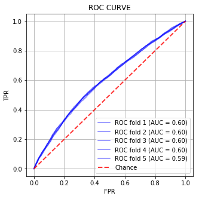

```python
#kfold = Kfold(k=5)
kf = KFold(n_splits=5)
result = pd.DataFrame()
idx = 1
for train_indices, test_indices in kf.split(kaggle):
    train_df = kaggle.iloc[train_indices]
    test_df = kaggle.iloc[test_indices]

    train_patient_label = train_df['PatientId']
    train_appointment_label = train_df['AppointmentID']

    test_patient_label = test_df['PatientId']
    test_appointment_label = test_df['AppointmentID']


    train_df=train_df.drop(columns = ['PatientId','AppointmentID'])
    test_df=test_df.drop(columns = ['PatientId','AppointmentID'])

    y_true, y_pred = train(train_df, test_df).classify(model=BernoulliNB(alpha=best_alpha))


    temp_df = pd.DataFrame({"PatientId": test_patient_label,"AppointmentId":test_appointment_label, "FOLD": idx, "ACTUAL": y_true, "PREDICTED": y_pred})
    result = result.append(temp_df, ignore_index = True)


    idx += 1


result = result[["PatientId", "AppointmentId", "FOLD", "ACTUAL", "PREDICTED"]]

arity = result['FOLD'].nunique()
pat_id, app_id, fold, actual, pred = result
plt.figure(figsize=(5,5))
for i in range(1, arity+1):
    pred_val, actual_val = result[result[fold] == i][pred].values, result[result[fold] == i][actual].values
    fpr, tpr, thresholds = roc_curve(actual_val, pred_val, pos_label=1)
    auc_roc = np.trapz(tpr, fpr)
    plt.plot(fpr, tpr, linestyle='-', alpha=0.5, color='b', label='ROC fold %d (AUC = %0.2f)' % (i, auc_roc))

    pred_val = list(map(lambda x:1 if x >= 0.5 else 0, pred_val))
    acc = accuracy_score(actual_val, pred_val)
    f1_sc = f1_score(actual_val, pred_val)
    print('-----------------------')
    print('Accuracy: {}'.format(acc))
    print('F1_sc: {}'.format(f1_sc))

plt.plot([0, 1], [0, 1], linestyle='--', lw=2, color='r', label='Chance', alpha=.8)

plt.xlabel("FPR")
plt.ylabel("TPR")
plt.title('ROC CURVE')
plt.legend(loc="lower right")
plt.grid()
plt.show()
```

#### c. Random Forest Default ROC

```
              importance
Age             0.606943
SMS_received    0.145485
Gender          0.036125
Scholarship     0.022882
Diabetes        0.021346
              importance
Age             0.594742
SMS_received    0.157661
Gender          0.033560
Scholarship     0.021552
Hipertension    0.020428
              importance
Age             0.591261
SMS_received    0.165586
Gender          0.032210
Scholarship     0.021844
Hipertension    0.020747
              importance
Age             0.584362
SMS_received    0.178161
Gender          0.041583
Hipertension    0.019837
Scholarship     0.019803
              importance
Age             0.585566
SMS_received    0.175750
Gender          0.032212
Hipertension    0.025591
Scholarship     0.022064
-----------------------
Accuracy: 0.7969350825605067
F1_sc: 0.02125919869174162
-----------------------
Accuracy: 0.7946615393315614
F1_sc: 0.01891380707916779
-----------------------
Accuracy: 0.7973760108578861
F1_sc: 0.02290700845377693
-----------------------
Accuracy: 0.8002035853644743
F1_sc: 0.02051566398669254
-----------------------
Accuracy: 0.7950573997624838
F1_sc: 0.018949648077964266
```

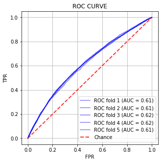

```python
#kfold = Kfold(k=5)
kf = KFold(n_splits=5)
result = pd.DataFrame()
idx = 1
for train_indices, test_indices in kf.split(kaggle):
    train_df = kaggle.iloc[train_indices]
    test_df = kaggle.iloc[test_indices]

    train_patient_label = train_df['PatientId']
    train_appointment_label = train_df['AppointmentID']

    test_patient_label = test_df['PatientId']
    test_appointment_label = test_df['AppointmentID']

    train_df=train_df.drop(columns = ['PatientId','AppointmentID'])
    test_df=test_df.drop(columns = ['PatientId','AppointmentID'])

    y_true, y_pred = train(train_df, test_df).classify(model=RandomForestClassifier(max_depth=best_depth,random_state=42))


    temp_df = pd.DataFrame({"PatientId": test_patient_label,"AppointmentId":test_appointment_label, "FOLD": idx, "ACTUAL": y_true, "PREDICTED": y_pred})
    result = result.append(temp_df, ignore_index = True)


    idx += 1


result = result[["PatientId", "AppointmentId", "FOLD", "ACTUAL", "PREDICTED"]]

arity = result['FOLD'].nunique()
pat_id, app_id, fold, actual, pred = result
plt.figure(figsize=(5,5))
for i in range(1, arity+1):
    pred_val, actual_val = result[result[fold] == i][pred].values, result[result[fold] == i][actual].values
    fpr, tpr, thresholds = roc_curve(actual_val, pred_val, pos_label=1)
    auc_roc = np.trapz(tpr, fpr)
    plt.plot(fpr, tpr, linestyle='-', alpha=0.5, color='b', label='ROC fold %d (AUC = %0.2f)' % (i, auc_roc))

    pred_val = list(map(lambda x:1 if x >= 0.5 else 0, pred_val))
    acc = accuracy_score(actual_val, pred_val)
    f1_sc = f1_score(actual_val, pred_val)
    print('-----------------------')
    print('Accuracy: {}'.format(acc))
    print('F1_sc: {}'.format(f1_sc))

plt.plot([0, 1], [0, 1], linestyle='--', lw=2, color='r', label='Chance', alpha=.8)

plt.xlabel("FPR")
plt.ylabel("TPR")
plt.title('ROC CURVE')
plt.legend(loc="lower right")
plt.grid()
plt.show()
```

### Analysis of our basic modeling

From our previous EDA, and the relatively high accuracy scores for each model, we immediately believed there was some sort of issue with our default data. The AUC scores from the ROC curves, which is the main metric we use to determine our best model later, seemed relatively similar as well.

After some researching, we determined that class imbalance was our issue. We also learned that ROC curves and AUC scores are insensitive to class imbalace. In the next step, we observed that insensitivity. The curves don't change even after resolving class imbalance. Furthermore, we also learned that in cases with class imbalance, accuracy scores are relatively high. Again, in the next step, after fixing class imbalance, those accuracy scores decrease.

Finally, we decided to bring in another metric such as F1_score (balance between precision and recall) to test whether class imbalance was really the issue. For each model above, the F1_score is almost close to zero.

### 3. Handle Imbalance

#### a. Logistic Regression Handled Imbalance ROC

```
-----------------------
Accuracy: 0.6154716127572948
F1_sc: 0.34815950920245403
-----------------------
Accuracy: 0.6047616354690946
F1_sc: 0.34870934675239956
-----------------------
Accuracy: 0.6146015947520217
F1_sc: 0.34540389972144847
-----------------------
Accuracy: 0.6220663914494147
F1_sc: 0.34164121761402816
-----------------------
Accuracy: 0.5962789119493299
F1_sc: 0.3479769841994703
```

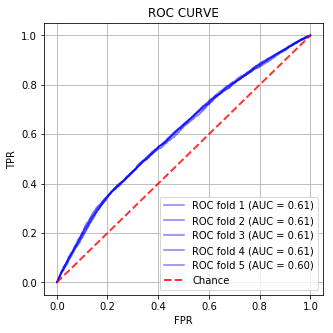

```python
#kfold = Kfold(k=5)
kf = KFold(n_splits=5)
result = pd.DataFrame()
idx = 1.
for train_indices, test_indices in kf.split(kaggle):
    train_df = kaggle.iloc[train_indices]
    test_df = kaggle.iloc[test_indices]

    ###Down-sampling for class imbalance

    minority = train_df[train_df["NoShow"] == 1]
    majority = train_df[train_df["NoShow"] == 0]

    downsample = resample(majority, replace=False, n_samples=train_df["NoShow"].value_counts()[1])
    train_df = pd.concat([downsample, minority])

    train_patient_label = train_df['PatientId']
    train_appointment_label = train_df['AppointmentID']

    test_patient_label = test_df['PatientId']
    test_appointment_label = test_df['AppointmentID']


    train_df=train_df.drop(columns = ['PatientId','AppointmentID'])
    test_df=test_df.drop(columns = ['PatientId','AppointmentID'])

    y_true, y_pred = train(train_df, test_df).classify(model = LogisticRegression(C=best_cLR,random_state=42))


    temp_df = pd.DataFrame({"PatientId": test_patient_label,"AppointmentId":test_appointment_label, "FOLD": idx, "ACTUAL": y_true, "PREDICTED": y_pred})
    result = result.append(temp_df, ignore_index = True)


    idx += 1


result = result[["PatientId", "AppointmentId", "FOLD", "ACTUAL", "PREDICTED"]]

arity = result['FOLD'].nunique()
pat_id, app_id, fold, actual, pred = result
plt.figure(figsize=(5,5))
for i in range(1, arity+1):
    pred_val, actual_val = result[result[fold] == i][pred].values, result[result[fold] == i][actual].values
    fpr, tpr, thresholds = roc_curve(actual_val, pred_val, pos_label=1)
    auc_roc = np.trapz(tpr, fpr)
    plt.plot(fpr, tpr, linestyle='-', alpha=0.5, color='b', label='ROC fold %d (AUC = %0.2f)' % (i, auc_roc))

    pred_val = list(map(lambda x:1 if x >= 0.5 else 0, pred_val))
    acc = accuracy_score(actual_val, pred_val)
    f1_sc = f1_score(actual_val, pred_val)
    print('-----------------------')
    print('Accuracy: {}'.format(acc))
    print('F1_sc: {}'.format(f1_sc))

plt.plot([0, 1], [0, 1], linestyle='--', lw=2, color='r', label='Chance', alpha=.8)

plt.xlabel("FPR")
plt.ylabel("TPR")
plt.title('ROC CURVE')
plt.legend(loc="lower right")
plt.grid()
plt.show()
```

#### b. Naive Bayes Handled Imbalance ROC

```
-----------------------
Accuracy: 0.6123614566840081
F1_sc: 0.3484459652124323
-----------------------
Accuracy: 0.6125091896171464
F1_sc: 0.3549237431745434
-----------------------
Accuracy: 0.6174857207487418
F1_sc: 0.34986543637062667
-----------------------
Accuracy: 0.6185601990612453
F1_sc: 0.34380776340110913
-----------------------
Accuracy: 0.6013685460611887
F1_sc: 0.3471334629989812
```

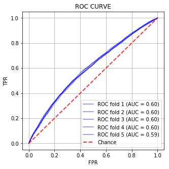

```python
#kfold = Kfold(k=5)
kf = KFold(n_splits=5)
result = pd.DataFrame()
idx = 1
for train_indices, test_indices in kf.split(kaggle):
    train_df = kaggle.iloc[train_indices]
    test_df = kaggle.iloc[test_indices]

    ###Down-sampling for class imbalance

    minority = train_df[train_df["NoShow"] == 1]
    majority = train_df[train_df["NoShow"] == 0]

    downsample = resample(majority, replace=False, n_samples=train_df["NoShow"].value_counts()[1])
    train_df = pd.concat([downsample, minority])


    train_patient_label = train_df['PatientId']
    train_appointment_label = train_df['AppointmentID']

    test_patient_label = test_df['PatientId']
    test_appointment_label = test_df['AppointmentID']


    train_df=train_df.drop(columns = ['PatientId','AppointmentID'])
    test_df=test_df.drop(columns = ['PatientId','AppointmentID'])

    y_true, y_pred = train(train_df, test_df).classify(model=BernoulliNB(alpha=best_alpha))


    temp_df = pd.DataFrame({"PatientId": test_patient_label,"AppointmentId":test_appointment_label, "FOLD": idx, "ACTUAL": y_true, "PREDICTED": y_pred})
    result = result.append(temp_df, ignore_index = True)


    idx += 1


result = result[["PatientId", "AppointmentId", "FOLD", "ACTUAL", "PREDICTED"]]

arity = result['FOLD'].nunique()
pat_id, app_id, fold, actual, pred = result
plt.figure(figsize=(5,5))
for i in range(1, arity+1):
    pred_val, actual_val = result[result[fold] == i][pred].values, result[result[fold] == i][actual].values
    fpr, tpr, thresholds = roc_curve(actual_val, pred_val, pos_label=1)
    auc_roc = np.trapz(tpr, fpr)
    plt.plot(fpr, tpr, linestyle='-', alpha=0.5, color='b', label='ROC fold %d (AUC = %0.2f)' % (i, auc_roc))
    pred_val = list(map(lambda x:1 if x >= 0.5 else 0, pred_val))
    acc = accuracy_score(actual_val, pred_val)
    f1_sc = f1_score(actual_val, pred_val)
    print('-----------------------')
    print('Accuracy: {}'.format(acc))
    print('F1_sc: {}'.format(f1_sc))

plt.plot([0, 1], [0, 1], linestyle='--', lw=2, color='r', label='Chance', alpha=.8)

plt.xlabel("FPR")
plt.ylabel("TPR")
plt.title('ROC CURVE')
plt.legend(loc="lower right")
plt.grid()
plt.show()
```

#### c. Random Forest Handled Imbalance ROC

```
              importance
Age             0.557113
SMS_received    0.166427
Gender          0.036457
Hipertension    0.029725
Scholarship     0.019824
              importance
Age             0.572583
SMS_received    0.158418
Gender          0.034437
Scholarship     0.022376
Hipertension    0.020800
              importance
Age             0.585361
SMS_received    0.161742
Gender          0.030502
Hipertension    0.027556
Scholarship     0.021913
              importance
Age             0.562024
SMS_received    0.167227
Gender          0.031778
Scholarship     0.025243
Diabetes        0.019201
              importance
Age             0.558196
SMS_received    0.165879
Gender          0.036320
Hipertension    0.024240
Scholarship     0.020391
-----------------------
Accuracy: 0.6182424790771319
F1_sc: 0.3537857758208098
-----------------------
Accuracy: 0.6161850364757111
F1_sc: 0.3567434366410767
-----------------------
Accuracy: 0.6239325906237629
F1_sc: 0.35235683677444485
-----------------------
Accuracy: 0.6215574280382288
F1_sc: 0.35066951290510384
-----------------------
Accuracy: 0.6125657411072781
F1_sc: 0.346465706381761
```

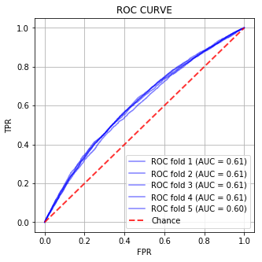

```python
kf = KFold(n_splits=5)
result = pd.DataFrame()
idx = 1
for train_indices, test_indices in kf.split(kaggle):
    train_df = kaggle.iloc[train_indices]
    test_df = kaggle.iloc[test_indices]

    ###Down-sampling for class imbalance

    minority = train_df[train_df["NoShow"] == 1]
    majority = train_df[train_df["NoShow"] == 0]
    downsample = resample(majority, replace=False, n_samples=train_df["NoShow"].value_counts()[1])
    train_df = pd.concat([downsample, minority])

    train_patient_label = train_df['PatientId']
    train_appointment_label = train_df['AppointmentID']

    test_patient_label = test_df['PatientId']
    test_appointment_label = test_df['AppointmentID']


    train_df=train_df.drop(columns = ['PatientId','AppointmentID'])
    test_df=test_df.drop(columns = ['PatientId','AppointmentID'])

    y_true, y_pred = train(train_df, test_df).classify(model=RandomForestClassifier(max_depth=best_depth,random_state=42))


    temp_df = pd.DataFrame({"PatientId": test_patient_label,"AppointmentId":test_appointment_label, "FOLD": idx, "ACTUAL": y_true, "PREDICTED": y_pred})
    result = result.append(temp_df, ignore_index = True)


    idx += 1


result = result[["PatientId", "AppointmentId", "FOLD", "ACTUAL", "PREDICTED"]]

arity = result['FOLD'].nunique()
pat_id, app_id, fold, actual, pred = result
plt.figure(figsize=(5,5))
for i in range(1, arity+1):
    pred_val, actual_val = result[result[fold] == i][pred].values, result[result[fold] == i][actual].values
    fpr, tpr, thresholds = roc_curve(actual_val, pred_val, pos_label=1)
    auc_roc = np.trapz(tpr, fpr)
    plt.plot(fpr, tpr, linestyle='-', alpha=0.5, color='b', label='ROC fold %d (AUC = %0.2f)' % (i, auc_roc))

    pred_val = list(map(lambda x:1 if x >= 0.5 else 0, pred_val))
    acc = accuracy_score(actual_val, pred_val)
    f1_sc = f1_score(actual_val, pred_val)
    print('-----------------------')
    print('Accuracy: {}'.format(acc))
    print('F1_sc: {}'.format(f1_sc))


plt.plot([0, 1], [0, 1], linestyle='--', lw=2, color='r', label='Chance', alpha=.8)

plt.xlabel("FPR")
plt.ylabel("TPR")
plt.title('ROC CURVE')
plt.legend(loc="lower right")
plt.grid()
plt.show()
```

To fix class imbalance, we down-sampled the majority class. Another approach that could have been taken is to upsample the minority class. I assume upsampling is a better approach because you don't end up losing any data points.

As mentioned above, even after resolving class imbalance, none of the ROC Curves for any of the models changed. However, the accuracy scores for the seperate models decreased, while the F1-score increased for each model. This supported our intuition that class imbalance was an issue that needed to be resolved.

### 4. Adding features

Over here, we decided to add three additional features. The first feature we decided to add was the days between the appointment day and the scheduled day. We believed this was important because generally people won't miss an appointment if you have scheduled it for an immediate date. If there is an appointment that is booked a month in prior you might not be very serious about the appointment.

In addition, from the age feature, we created bins for the different age groups. We extracted bins for baby, child, teenager, young adults, adult, and elder categories.

The next feature we added was whether the appointment was a followup or not. We believed this was important under the assumption that people generally tend to miss their appointments if its a follow up appointment.

```python
dataAdditionalFeatures = X_train.copy()
#Adding days between the scheduled date and the actual appointment date
dataAdditionalFeatures['DaysBetween'] = (dataAdditionalFeatures['AppointmentDay'].dt.date - dataAdditionalFeatures['ScheduledDay'].dt.date).map(lambda val: int(str(val).strip().split()[0]))


#Split the age in different categories. We take -1 so that zero is inclusive
bins = [-1,2,12,18,35,60,np.inf]
age_labels=["Baby","Child","Teenager","Young adults", "Adult","Elder"]
age_cat = pd.cut(data_raw.Age,bins,labels=age_labels)
#making age category as object type so that encoding works
age_cat = age_cat.astype('object')
dataAdditionalFeatures['Age_category'] = age_cat
dataAdditionalFeatures = encoding(dataAdditionalFeatures)
```

```python
#Find if appointment is a followup
dataAdditionalFeatures =dataAdditionalFeatures.sort_values(by=['PatientId', 'AppointmentDay'], ascending=[True,True]).reset_index()
dataAdditionalFeatures['isFollowUp'] = 0
for index, row in dataAdditionalFeatures.iterrows():
    if(index!=len(dataAdditionalFeatures)-1):
        if(row['PatientId']==dataAdditionalFeatures.iloc[index+1]['PatientId']):
            if(int(str(dataAdditionalFeatures.iloc[index+1]['AppointmentDay']-row['AppointmentDay']).strip().split()[0])<=30):
                dataAdditionalFeatures.set_value(index,'isFollowUp',1)
```

```python
kaggle_addFeatures = dataAdditionalFeatures.copy()
kaggle_addFeatures.drop(['AppointmentDay','ScheduledDay','index'], axis=1,inplace=True)
kaggle_addFeatures['NoShow'] = kaggle_addFeatures['No-show']
kaggle_addFeatures.drop(['No-show'], axis=1,inplace=True)
```

#### a. Hyper parameter tuning

Below we tune the hyper-parameters of all the models again as the dataset now has added features and we wanted to account for them.

```python
logistic = LogisticRegression()
C = [1e-2,1e-1,1,10,100]

hyperparameters = dict(C=C)
clf = GridSearchCV(logistic, hyperparameters, cv=5, verbose=0, scoring='roc_auc')

n,m = kaggle_addFeatures.shape
X, Y = kaggle_addFeatures.iloc[:,:m-1], kaggle_addFeatures.iloc[:,m-1]
best_model = clf.fit(X, Y)

print('Best Parameters',clf.best_params_)
print('Best C:', best_model.best_estimator_.get_params()['C'])
best_cLR2 = best_model.best_estimator_.get_params()['C']

bNB = BernoulliNB()
alphas = np.array([0.001,0.01,0.1,1,10,100])

hyperparameters = dict(alpha=alphas)
clf = GridSearchCV(bNB, hyperparameters, cv=5, verbose=0, scoring='roc_auc')

n,m = kaggle_addFeatures.shape
X, Y = kaggle_addFeatures.iloc[:,:m-1], kaggle_addFeatures.iloc[:,m-1]
best_model = clf.fit(X, Y)

print('Best Parameters',clf.best_params_)
print('Best alpha:', best_model.best_estimator_.get_params()['alpha'])
best_alpha2 = best_model.best_estimator_.get_params()['alpha']

rb = RandomForestClassifier()
depths = max_depth = [int(x) for x in np.linspace(2, 50, num = 10)]
print(depths)
hyperparameters = dict(max_depth=depths)
clf = GridSearchCV(rb, hyperparameters, cv=5, verbose=0, scoring='roc_auc')

n,m = kaggle_addFeatures.shape
X, Y = kaggle_addFeatures.iloc[:,:m-1], kaggle_addFeatures.iloc[:,m-1]
best_model = clf.fit(X, Y)

print('Best Parameters',clf.best_params_)
print('Best depth:', best_model.best_estimator_.get_params()['max_depth'])
best_depth2 = best_model.best_estimator_.get_params()['max_depth']
```

```
Best Parameters {'C': 0.01}
Best C: 0.01
Best Parameters {'alpha': 1.0}
Best alpha: 1.0
[2, 7, 12, 18, 23, 28, 34, 39, 44, 50]
Best Parameters {'max_depth': 12}
Best depth: 12
```

After adding the previous features, we re-tuned the models, and obtained 0.01, 1.0, and 12 for the best C, best alpha, and best depth of logistic regression, naive bayes, and random forest, respectively.

#### b. Hyper parameter tuning for clustering

Another feature we wanted to add to see if we could improve the classification task was the output of K-means clustering. Before adding that feature, we tuned the clustering model to determine the optimal K for K-means clustering. By plotting the sum of squared distances for different K's, we obtained the elbow plot above. Based on the elbow plot above, the best number of clusters is 3.

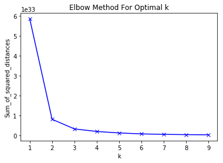

```python
Sum_of_squared_distances = []
K = range(1,10)
n,m = kaggle_addFeatures.shape
for k in K:
    km = KMeans(n_clusters=k)
    #drop the last column which is the "y"
    km = km.fit(kaggle_addFeatures.iloc[:,:m-1])
    Sum_of_squared_distances.append(km.inertia_)

plt.plot(K, Sum_of_squared_distances, 'bx-')
plt.xlabel('k')
plt.ylabel('Sum_of_squared_distances')
plt.title('Elbow Method For Optimal k')
plt.show()
```

#### c. Running the models

##### 1. Logistic Regression with additional features + imbalance handled

```
F1_sc: 0.0
F1_sc: 0.3392345621037802
F1_sc: 0.0
F1_sc: 0.0
F1_sc: 0.0
```

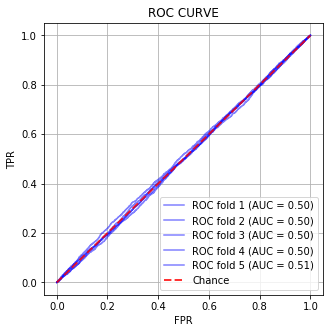

```python
#kfold = Kfold(k=5)
kf = KFold(n_splits=5)
result = pd.DataFrame()
idx = 1.
for train_indices, test_indices in kf.split(kaggle_addFeatures):
    train_df = kaggle.iloc[train_indices]
    test_df = kaggle.iloc[test_indices]

    ###Down-sampling for class imbalance

    minority = train_df[train_df["NoShow"] == 1]
    majority = train_df[train_df["NoShow"] == 0]
    downsample = resample(majority, replace=False, n_samples=train_df["NoShow"].value_counts()[1])
    train_df = pd.concat([downsample, minority])

    train_patient_label = train_df['PatientId']
    train_appointment_label = train_df['AppointmentID']

    test_patient_label = test_df['PatientId']
    test_appointment_label = test_df['AppointmentID']

    train_df.drop(columns = ['PatientId','AppointmentID'])
    train_df.drop(columns = ['PatientId','AppointmentID'])

    test_df.drop(columns = ['PatientId','AppointmentID'])
    test_df.drop(columns = ['PatientId','AppointmentID'])

    y_true, y_pred = train(train_df, test_df).cluster(model=KMeans(n_clusters=3, random_state=42), output='add').classify(model = LogisticRegression(C=best_cLR2,random_state=42))


    temp_df = pd.DataFrame({"PatientId": test_patient_label,"AppointmentId":test_appointment_label, "FOLD": idx, "ACTUAL": y_true, "PREDICTED": y_pred})
    result = result.append(temp_df, ignore_index = True)


    idx += 1


result = result[["PatientId", "AppointmentId", "FOLD", "ACTUAL", "PREDICTED"]]

arity = result['FOLD'].nunique()
pat_id, app_id, fold, actual, pred = result
plt.figure(figsize=(5,5))
for i in range(1, arity+1):
    pred_val, actual_val = result[result[fold] == i][pred].values, result[result[fold] == i][actual].values
    fpr, tpr, thresholds = roc_curve(actual_val, pred_val, pos_label=1)
    auc_roc = np.trapz(tpr, fpr)
    plt.plot(fpr, tpr, linestyle='-', alpha=0.5, color='b', label='ROC fold %d (AUC = %0.2f)' % (i, auc_roc))

    pred_val = list(map(lambda x:1 if x >= 0.5 else 0, pred_val))
    acc = accuracy_score(actual_val, pred_val)
    f1_sc = f1_score(actual_val, pred_val)
    print('F1_sc: {}'.format(f1_sc))

plt.plot([0, 1], [0, 1], linestyle='--', lw=2, color='r', label='Chance', alpha=.8)

plt.xlabel("FPR")
plt.ylabel("TPR")
plt.title('ROC CURVE')
plt.legend(loc="lower right")
plt.grid()
plt.show()
```

##### 2. Naive Bayes with additional features + imbalance handled

```
F1_sc: 0.35282164957975437
F1_sc: 0.3583771600300526
F1_sc: 0.345703125
F1_sc: 0.3433443865466604
F1_sc: 0.34799700486709095
```

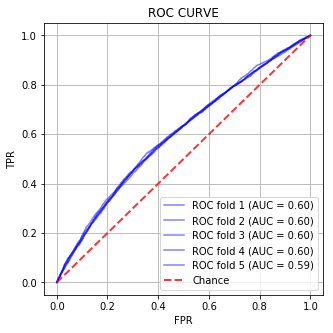

```python
#kfold = Kfold(k=5)
kf = KFold(n_splits=5)
result = pd.DataFrame()
idx = 1
for train_indices, test_indices in kf.split(kaggle_addFeatures):
    train_df = kaggle.iloc[train_indices]
    test_df = kaggle.iloc[test_indices]

    ###Down-sampling for class imbalance

    minority = train_df[train_df["NoShow"] == 1]
    majority = train_df[train_df["NoShow"] == 0]
    downsample = resample(majority, replace=False, n_samples=train_df["NoShow"].value_counts()[1])
    train_df = pd.concat([downsample, minority])

    train_patient_label = train_df['PatientId']
    train_appointment_label = train_df['AppointmentID']

    test_patient_label = test_df['PatientId']
    test_appointment_label = test_df['AppointmentID']

    train_df.drop(columns = ['PatientId','AppointmentID'])
    train_df.drop(columns = ['PatientId','AppointmentID'])

    test_df.drop(columns = ['PatientId','AppointmentID'])
    test_df.drop(columns = ['PatientId','AppointmentID'])

    y_true, y_pred = train(train_df, test_df).cluster(model=KMeans(n_clusters=3, random_state=42), output='add').classify(model=BernoulliNB(alpha=best_alpha2))


    temp_df = pd.DataFrame({"PatientId": test_patient_label,"AppointmentId":test_appointment_label, "FOLD": idx, "ACTUAL": y_true, "PREDICTED": y_pred})
    result = result.append(temp_df, ignore_index = True)


    idx += 1


result = result[["PatientId", "AppointmentId", "FOLD", "ACTUAL", "PREDICTED"]]

arity = result['FOLD'].nunique()
pat_id, app_id, fold, actual, pred = result
plt.figure(figsize=(5,5))
for i in range(1, arity+1):
    pred_val, actual_val = result[result[fold] == i][pred].values, result[result[fold] == i][actual].values
    fpr, tpr, thresholds = roc_curve(actual_val, pred_val, pos_label=1)
    auc_roc = np.trapz(tpr, fpr)
    plt.plot(fpr, tpr, linestyle='-', alpha=0.5, color='b', label='ROC fold %d (AUC = %0.2f)' % (i, auc_roc))

    pred_val = list(map(lambda x:1 if x >= 0.5 else 0, pred_val))
    acc = accuracy_score(actual_val, pred_val)
    f1_sc = f1_score(actual_val, pred_val)
    print('F1_sc: {}'.format(f1_sc))

plt.plot([0, 1], [0, 1], linestyle='--', lw=2, color='r', label='Chance', alpha=.8)

plt.xlabel("FPR")
plt.ylabel("TPR")
plt.title('ROC CURVE')
plt.legend(loc="lower right")
plt.grid()
plt.show()
```

##### 3. Random Forest with additional features + imbalance handled

```
              importance
DaysBetween     0.602968
Age             0.085963
SMS_received    0.072489
km_clust        0.034493
isFollowUp      0.020635
              importance
DaysBetween     0.637973
Age             0.081430
km_clust        0.059709
SMS_received    0.032551
isFollowUp      0.020567
              importance
DaysBetween     0.631862
Age             0.083008
SMS_received    0.061115
km_clust        0.043896
isFollowUp      0.018476
              importance
DaysBetween     0.550158
Age             0.098529
SMS_received    0.078617
km_clust        0.059476
isFollowUp      0.024962
              importance
DaysBetween     0.573340
Age             0.087513
SMS_received    0.075497
km_clust        0.071142
isFollowUp      0.018233
F1_sc: 0.4379908134538451
F1_sc: 0.44322370798698957
F1_sc: 0.43612431444241323
F1_sc: 0.4405997693194924
F1_sc: 0.4435712040238919
```

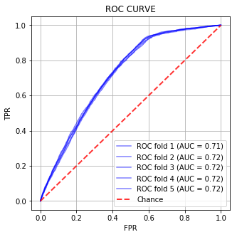

```python
#kfold = Kfold(k=5)
kf = KFold(n_splits=5)
result = pd.DataFrame()
idx = 1
for train_indices, test_indices in kf.split(kaggle_addFeatures):
    train_df = kaggle_addFeatures.iloc[train_indices]
    test_df = kaggle_addFeatures.iloc[test_indices]

    minority = train_df[train_df["NoShow"] == 1]
    majority = train_df[train_df["NoShow"] == 0]
    downsample = resample(majority, replace=False, n_samples=train_df["NoShow"].value_counts()[1])
    train_df = pd.concat([downsample, minority])

    train_patient_label = train_df['PatientId']
    train_appointment_label = train_df['AppointmentID']

    test_patient_label = test_df['PatientId']
    test_appointment_label = test_df['AppointmentID']

    train_df=train_df.drop(columns = ['PatientId','AppointmentID'])
    test_df=test_df.drop(columns = ['PatientId','AppointmentID'])

    y_true, y_pred = train(train_df, test_df).cluster(model=KMeans(n_clusters=3, random_state=42), output='add').classify(model=RandomForestClassifier(max_depth=best_depth2,random_state=42))


    temp_df = pd.DataFrame({"PatientId": test_patient_label,"AppointmentId":test_appointment_label, "FOLD": idx, "ACTUAL": y_true, "PREDICTED": y_pred})
    result = result.append(temp_df, ignore_index = True)


    idx += 1


result = result[["PatientId", "AppointmentId", "FOLD", "ACTUAL", "PREDICTED"]]

arity = result['FOLD'].nunique()
pat_id, app_id, fold, actual, pred = result
plt.figure(figsize=(5,5))
for i in range(1, arity+1):
    pred_val, actual_val = result[result[fold] == i][pred].values, result[result[fold] == i][actual].values
    fpr, tpr, thresholds = roc_curve(actual_val, pred_val, pos_label=1)
    auc_roc = np.trapz(tpr, fpr)
    plt.plot(fpr, tpr, linestyle='-', alpha=0.5, color='b', label='ROC fold %d (AUC = %0.2f)' % (i, auc_roc))

    pred_val = list(map(lambda x:1 if x >= 0.5 else 0, pred_val))
    acc = accuracy_score(actual_val, pred_val)
    f1_sc = f1_score(actual_val, pred_val)
    print('F1_sc: {}'.format(f1_sc))

plt.plot([0, 1], [0, 1], linestyle='--', lw=2, color='r', label='Chance', alpha=.8)

plt.xlabel("FPR")
plt.ylabel("TPR")
plt.title('ROC CURVE')
plt.legend(loc="lower right")
plt.grid()
plt.show()
```

After adding the four additional features, Random Forest was the best model. The Random Forest model had the highest AUC score of 0.72. In addition, the F1-score after adding the 4 features was highest for this model with an F1-score of about 0.44. However, the F1-score is overall low, and this is because our data itself is not informative enough. We only had so many features to work with. Again, we just want to state that we were able to increase the AUC scores as well as the F1-scores incrementally with the limited number of information we were provided in this dataset.

## IV. Results

### 1. Preparing the held out test data for final testing with Random Forest

We had held out 20% of the data at the start of itself. We now do the feature engineering on this data set as well so that it can be predicted with our finally trained model.

```python
X_test_addFeatures = X_test.copy()

#Adding days between the scheduled date and the actual appointment date
X_test_addFeatures['DaysBetween'] = (X_test_addFeatures['AppointmentDay'].dt.date - X_test_addFeatures['ScheduledDay'].dt.date).map(lambda val: int(str(val).strip().split()[0]))


#Split the age in different categories. We take -1 so that zero is inclusive
bins = [-1,2,12,18,35,60,np.inf]
age_labels=["Baby","Child","Teenager","Young adults", "Adult","Elder"]
age_cat = pd.cut(data_raw.Age,bins,labels=age_labels)
#making age category as object type so that encoding works
age_cat = age_cat.astype('object')
X_test_addFeatures['Age_category'] = age_cat
X_test_addFeatures = encoding(X_test_addFeatures)

#Find if appointment is a followup
X_test_addFeatures =X_test_addFeatures.sort_values(by=['PatientId', 'AppointmentDay'], ascending=[True,True]).reset_index()
X_test_addFeatures['isFollowUp'] = 0
for index, row in X_test_addFeatures.iterrows():
    if(index!=len(X_test_addFeatures)-1):
        if(row['PatientId']==X_test_addFeatures.iloc[index+1]['PatientId']):
            if(int(str(X_test_addFeatures.iloc[index+1]['AppointmentDay']-row['AppointmentDay']).strip().split()[0])<=30):
                X_test_addFeatures.set_value(index,'isFollowUp',1)

X_test_addFeatures.drop(['AppointmentDay','ScheduledDay','index'], axis=1,inplace=True)

#Move the output collumn to the end
X_test_addFeatures['NoShow'] = X_test_addFeatures['No-show']
X_test_addFeatures.drop(['No-show'], axis=1,inplace=True)
```

### 2. Fixing the class imbalance for the full train data

Earlier the class imbalance was always fixed for the train data in each fold. Now we are fixing it on the entire train data(80% split of the main data).

```python
kaggle_addFeatures_final = kaggle_addFeatures.copy()

minority = kaggle_addFeatures_final[kaggle_addFeatures_final["NoShow"] == 1]
majority = kaggle_addFeatures_final[kaggle_addFeatures_final["NoShow"] == 0]
downsample = resample(majority, replace=False, n_samples=kaggle_addFeatures_final["NoShow"].value_counts()[1])
kaggle_addFeatures_final = pd.concat([downsample, minority])

kaggle_addFeatures_final.drop(["PatientId", "AppointmentID"],axis=1,inplace=True)
X_test_addFeatures.drop(["PatientId", "AppointmentID"],axis=1,inplace=True)

n,m = kaggle_addFeatures_final.shape
X_train_final, y_train_final = kaggle_addFeatures_final.iloc[:,:m-1], kaggle_addFeatures_final.iloc[:,m-1]
X_test_final, y_test_final = X_test_addFeatures.iloc[:, :m-1], X_test_addFeatures.iloc[:, m-1]
```

### 3. Adding the clustering feature to the train and test set

Along with the three features, we are also adding the clustering output as one of the feature to both our train and test data

```python
#Add the cluster labels to both test and train
kmeans_final=KMeans(n_clusters=3, random_state=42)
kmeans_final.fit(X_train_final)
y_labels_train = kmeans_final.labels_
y_labels_test = kmeans_final.predict(X_test_final)
X_train_final['km_clust'] = y_labels_train
X_test_final['km_clust'] = y_labels_test
```

### 4. Fitting the Random Forest to the train data and testing it out on the test set. Plotting the results.

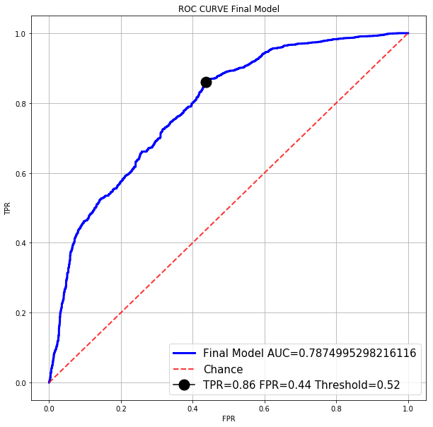

```python
rf_final_model=RandomForestClassifier(max_depth=best_depth2,random_state=42)
rf_final_model.fit(X_train_final,y_train_final)
y_predict_final_proba = rf_final_model.predict_proba(X_test_addFeatures)[:,1]
y_predict_final = rf_final_model.predict(X_test_addFeatures)


fpr, tpr, thresholds = roc_curve(y_test_final, y_predict_final_proba, pos_label=1)
auc_roc = np.trapz(tpr, fpr)

optimal_idx = np.argmax(np.abs(tpr-fpr))
optimal_threshold = thresholds[optimal_idx]
best_fpr = fpr[optimal_idx]
best_tpr = tpr[optimal_idx]

print(f1_score(y_test_final, y_predict_final))
plt.figure(figsize=(10,10))
plt.plot(fpr, tpr, label="Final Model AUC=" + str(auc_roc), lw=3, color='b')
plt.plot([0, 1], [0, 1], linestyle='--', lw=2, color='r', label='Chance', alpha=.8)
plt.plot([best_fpr], [best_tpr], marker='o', markersize=15, color="black", label = 'TPR={:0.2f} FPR={:0.2f} Threshold={:0.2f}'.format(best_tpr, best_fpr, optimal_threshold))
plt.xlabel("FPR")
plt.ylabel("TPR")
plt.title('ROC CURVE Final Model')
plt.legend(loc='lower right', prop={'size': 15})
plt.grid()
plt.show()
```

### 5. Best Features of our Final Model

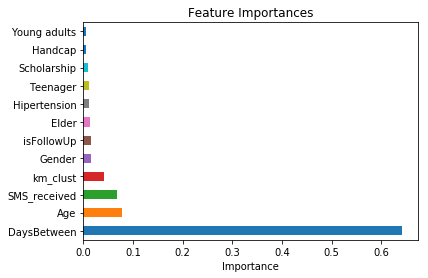

```python
feat_importances = pd.Series(rf_final_model.feature_importances_, index=X_train_final.columns)
feat_importances.nlargest(12).plot(kind='barh')
plt.title('Feature Importances')
plt.xlabel('Importance')
plt.show()
```

After viewing the feature importance plot, it seems that DaysBetween and km_clust ranked in the top 5. This is interesting because these are features that we created. The DaysBetween seems to be dominating in terms of feature importance.

### 6. EDA performed on patients that were misclassified and classified by our best model.

Depending on the best threshold found we predicted the people who would show and not show. Further, we have found how many were correctly classified and not using their true values. We wanted to see if these people were inherently different in any way. This is a step further to help the business understand what kind of patients they should be focusing on.

#### 1. Result data

```python
result = X_test_addFeatures.copy()
result['pred'] = y_predict_final
result['pred'] = result['pred'].apply(lambda val: 1 if val > optimal_threshold else 0)
```

```python
result.to_csv('resulting_people.csv')
```

The result dataframe contains the results our final model. This is passed to a csv that is going to be used in tableau to make the visualizations.

#### 2. EDA on the tested set of people using the threshold

1. The first EDA tells us correctly classified and misclassified people's median and average age. And we can see that there isn't much of a difference in age group
2. The second EDA is across both the genders and even there we can see that there isn't much difference

This basically proves why the model couldn't classify them correctly. There isn't much of a difference in them. Which basically indicates that we need more information about the people so that the model can identify them correctly.

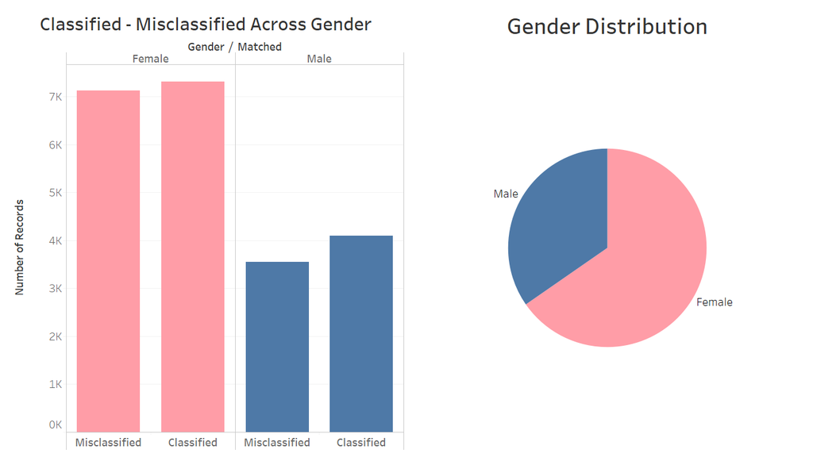

```python
Image(filename='test_data_eda.png')
```

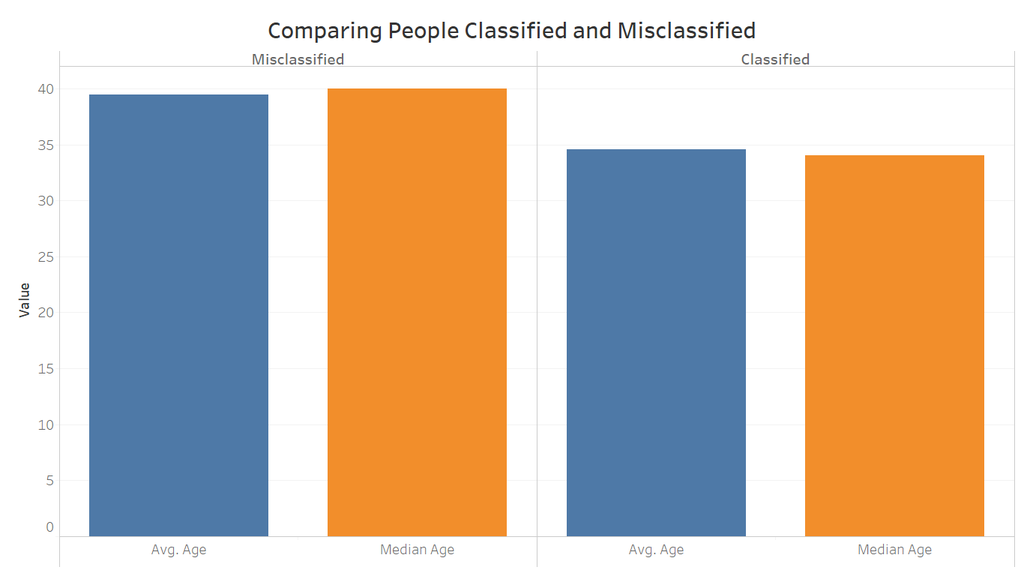

```python
Image(filename='test_data_eda2.png')
```

## V. Conclusion

Using this threshold, we were able to identiy the patients that were misclassified and classified by our model. After realizing that there is no systematic difference between the patients that were misclassified and classified, we realized that we needed more information to discern such a difference.

Therefore, our assessment should further incentivize hospitals to provide more information in hopes that models like ours can help more precisely determine whether a patient will miss their appointment or not. The extra information could include reasons why a patient is visiting the hospital, some cost parameter, and data that spans more than just three months. Ultimately, our assessment can help hospitals target patients that are more likely to skip there appointments, and reach out to them in advance to lower the rate of missed appointments.